# 301.0. Descripción general de DP1

Para la Plataforma Científica de Rubin en data.lsst.cloud.  
Divulgación de Datos: [Vista Previa de Datos 1](https://dp1.lsst.io)  
Tamaño del contenedor (Container size): large  
Versión de las Pipelines Científicas de LSST: r29.2.0  
Última verificación de ejecución: 2025-09-17  
Repositorio: github.com/lsst/tutorial-notebooks

**Objetivo de aprendizaje:** Obtener una descripción general de los campos objetivo de los datos de la Vista Previa de Datos 1 (DP1) obtenidos con LSSTComCam.

**Productos de datos LSST:**

**Paquetes:** `lsst.daf.butler`, `lsst.rsp`, `lsst.geom`

**Créditos:** Desarrollado originalmente por Andrés A. Plazas Malagón y por el equipo científico de la comunidad de Rubin. Las secciones 3, 4 y 5 están basadas en *notebooks* desarrollados para el artículo de DP1 en github.com/lsst/rtn-095. Por favor, considerar reconocer su trabajo si este *notebook* se utiliza para la preparación de artículos de revistas, lanzamientos de *software* u otros *notebooks*.

**Soporte:** Se invita a toda la comunidad a hacer preguntas o plantear problemas en la [Categoría de asistencia](https://community.lsst.org/c/support) del Foro de la Comunidad de Rubin. El equipo de Rubin responderá a todas las preguntas publicadas allí.

## 1. Introducción

Este notebook ofrece una descripción general y un análisis exploratorio de los siete campos objetivo observados durante la campaña de puesta a punto en el cielo (*on-sky commissioning campaign*) de la ComCam del Observatorio Vera C. Rubin.

Entre octubre y diciembre de 2024, la ComCam se utilizó para adquirir ∼16,000 exposiciones para ingeniería de sistemas, validación del rendimiento científico y pruebas tempranas de procesamiento de datos ([SITCOMTN-149](https://sitcomtn-149.lsst.io/)). Un subconjunto de estas exposiciones formó la base de la **Vista Previa de Datos 1 (DP1)**, ofreciendo a la comunidad científica la oportunidad de adquirir experiencia con datos y herramientas reales similares a los de LSST. Cada campo fue seleccionado para respaldar objetivos de validación específicos y casos de uso científico de LSST, cubriendo una amplia gama de posiciones en el cielo, densidades de objetos y superposición con conjuntos de datos externos.

**Tutoriales relacionados**: Otros tutoriales de la serie 301 sobre campos de la ComCam durante la puesta a punto en el cielo.

### 1.1. Descripción de los campos

**47 Tuc**  
Un campo estelar densamente poblado; 47 Tucanae fue seleccionado para las primeras pruebas de calidad de imagen y de rendimiento de alineación del Sistema de Óptica Activa (AOS - *Active Optic System*). La alta densidad estelar de este campo lo hace ideal para probar *pipelines* de fotometría en campos abarrotados.

**Campo de Baja Latitud Eclíptica (Rubin SV 38 7)**  
Este campo de baja latitud eclíptica fue seleccionado para optimizar el estudio científico del Sistema Solar. Se observó utilizando un patrón de grilla con *dithering* de 2x2 para facilitar el seguimiento de objetos en movimiento a lo largo de una región más amplia. Este campo respalda la ciencia del dominio temporal y pruebas relacionadas con la asociación de Objetos del Sistema Solar.

**Galaxia Esferoidal Enana (dSph) de Fornax**  
Centrado en la Galaxia Esferoidal Enana de Fornax, este campo es ideal para estudiar poblaciones estelares resueltas en una galaxia enana del Grupo Local.

**Campo Profundo Sur de Chandra Extendido (ECDFS)**  
El Campo Profundo Sur de Chandra Extendido (ECDFS - *Extended Chandra Deep Field South*) recibió la cobertura más densa y temporalmente consistente entre todos los campos, con cientos de visitas en los seis filtros. Se utilizó como el campo principal para la validación de la calibración fotométrica usando FGCM (*Forward Global Calibration Method* - método de calibración global directo), e incluye la estrella CalSpec C26202.

**Campo Profundo Sur de Euclid (EDFS)**  
Este campo se superpone con el Campo Profundo Sur de Euclid (*Euclid Deep Field South*) y fue seleccionado para probar *pipelines* de fotometría profunda y de lentes gravitacionales débiles. Aunque su cobertura en filtros es más limitada que la del ECDFS, es altamente relevante para ciencia extragaláctica y futuras comparaciones entre diferentes relevamientos (borrador del artículo de DP1, §2.1).

**Campo de Baja Latitud Galáctica (Rubin SV 95 -25)**  
Ubicado en una región de baja latitud Galáctica, este campo tiene una densidad estelar muy alta y es relevante para estudios de estructura Galáctica.

**Nebulosa de la Gaviota**  
Apuntando a una región cercana a la Nebulosa de la Gaviota (*Seagull Nebula*), este campo respalda estudios del medio interestelar (ISM) y formación estelar. Tiene una densidad estelar moderadamente alta y se incluyó para explorar fondos estructurados y variaciones en la calidad de imagen y calibración.

#### 1.1.1. Densidades estelares

Las densidades estelares varían significativamente entre los campos y fueron una consideración importante durante la selección de los mismos. Campos como **47 Tuc** y **Rubin SV 95 -25** contienen regiones de alta densidad estelar, poniendo a prueba los límites de las *pipelines* fotométricas y astrométricas bajo condiciones de campos abarrotados. En contraste, **ECDFS** y **EDFS** son campos extragalácticos con poblaciones estelares escasas, lo que permite coagregaciones profundas y ciencia de lentes gravitacionales débiles.

#### 1.1.2. Cadencia temporal

La cadencia temporal también varía según el campo y estuvo determinada por los objetivos científicos y la factibilidad operativa. **ECDFS** tuvo el muestreo más uniforme y con periodicidad nocturna, permitiendo estudios de imágenes diferenciales y de calibración fotométrica. **Rubin SV 38 7** fue visitado con un patrón de *dithering* estructurado a lo largo de múltiples noches para facilitar la investigación científica del Sistema Solar. Otros campos, como **Gaviota** (*Seagull*) y **Fornax**, recibieron una cobertura más dispersa pero igualmente valiosa a lo largo de distintos filtros y noches.

#### 1.1.3. Tabla resumen

Véase también la figura en la Sección 3.3.

[output not shown]

### 1.2. Importar paquetes

Importar `numpy`, un paquete fundamental para la computación científica con arreglos en Python (numpy.org), y `matplotlib`, una biblioteca completa para visualización de datos ([matplotlib.org](https://matplotlib.org/); [galería de matplotlib](https://matplotlib.org/stable/gallery/index.html)).

Del paquete `lsst`, importar módulos para acceder al servicio del Protocolo de Acceso a Datos Tabulados TAP (*Table Access Protocol*), *Butler* y las herramientas de geometría de las Pipelines Científicas de LSST ([pipelines.lsst.io](https://pipelines.lsst.io/)).

De `astropy`, importar módulos para transformaciones de coordenadas celestes, unidades y tablas ([astropy.org](https://www.astropy.org/)), y `astroplan` para trabajar con objetos astronómicos.

Usar `skyproj`, un paquete especializado en proyecciones del cielo, para crear mapas celestes consistentes ([skyproj](https://skyproj.readthedocs.io/en/latest/)).

Utilizar las herramientas de representación gráfica en `lsst.utils.plotting` para acceder a esquemas de colores, símbolos y estilos de línea estándar de LSST para visualizaciones multibanda.

```python
import numpy as np
import matplotlib.pyplot as plt
from astropy.coordinates import SkyCoord
import astropy.units as u
import skyproj

from lsst.rsp import get_tap_service
from lsst.daf.butler import Butler
from lsst.utils.plotting import (
    get_multiband_plot_colors,
    get_multiband_plot_symbols,
    get_multiband_plot_linestyles
)
```

### 1.3. Definir parámetros y funciones

Instanciar Butler con el repositorio, la colección y el mapa del cielo apropiados para DP1.

```python
butler = Butler('dp1', collections='LSSTComCam/DP1')
assert butler is not None
```

Instanciar el servicio TAP.

```python
service = get_tap_service("tap")
assert service is not None
```

Definir colores, símbolos y estilos de línea para representar los seis filtros de LSST, $ugrizy$, según lo definido en RTN-045.

```python
filter_names = ['u', 'g', 'r', 'i', 'z', 'y']
filter_colors = get_multiband_plot_colors()
filter_symbols = get_multiband_plot_symbols()
filter_linestyles = get_multiband_plot_linestyles()
```

Definir un diccionario con el nombre y las coordenadas centrales de cada campo, Ascensión Recta y Declinación, según lo definido en [SITCOMTN-149](https://sitcomtn-149.lsst.io/). Las siguientes son coordenadas del Sistema Internacional de Referencia Celeste (ICRS), expresadas en grados decimales.

```python
field_centers = {
    "47 Tuc": [6.02, -72.08],
    "SV 38 7": [37.86, 6.98],
    "Fornax": [40.00, -34.45],
    "ECDFS": [53.13, -28.10],
    "EDFS": [59.10, -48.73],
    "SV 95 -25": [95.00, -25.00],
    "Seagull": [106.23, -10.51],
}
field_names = list(field_centers.keys())
```

## 2. Mapa del cielo

Usar `skyproj` para visualizar los campos en la esfera celeste.

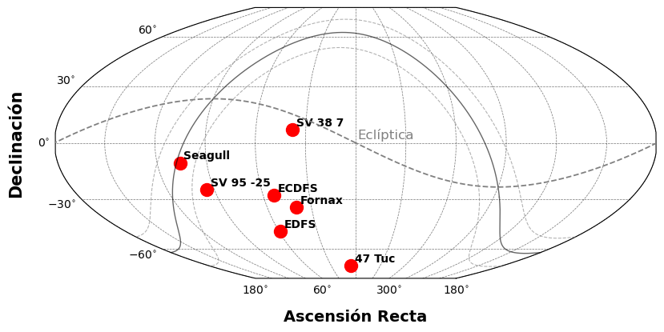

```python
fig, ax = plt.subplots(figsize=(8, 4))
sp = skyproj.McBrydeSkyproj(ax=ax, celestial=True, galactic=False, gridlines=True)
sp.ax.set_xlabel("Ascensión Recta", fontsize=14, fontweight="bold", labelpad=12)
sp.ax.set_ylabel("Declinación", fontsize=15, fontweight="bold", labelpad=12)

for name, (ra, dec) in field_centers.items():
    sp.ax.plot(ra, dec, marker="o", color="red", markersize=11.5)
    x, y = sp.proj(ra, dec)
    sp.ax.annotate(name, (x, y), fontsize=10, fontweight="bold",
                   textcoords="offset points", xytext=(3.4, 3.4))

ecl_lon = np.linspace(0, 360, 1000)
ecl_lat = np.zeros_like(ecl_lon)
ecl_eq = SkyCoord(ecl_lon * u.deg, ecl_lat * u.deg,
                  frame="geocentrictrueecliptic").transform_to("icrs")
ecl_ra = ecl_eq.ra.deg
ecl_dec = ecl_eq.dec.deg

sp.ax.plot(ecl_ra, ecl_dec, color="gray", linestyle="--", lw=1.3, zorder=5)
sp.ax.text(*sp.proj(260, 50), "Eclíptica", fontsize=12, color="gray",
           ha="left", va="bottom")

l_vals = np.linspace(0, 360, 1000)
for b in [0, 10, -10]:
    gal = SkyCoord(l_vals * u.deg, b * u.deg, frame="galactic")
    eq = gal.transform_to("icrs")
    sp.ax.plot(eq.ra.deg, eq.dec.deg,
               color="black" if b == 0 else "gray",
               linestyle="-" if b == 0 else "--",
               lw=1.0 if b == 0 else 0.8, alpha=0.6)

sp.ax.gridlines.set_edgecolor("black")
sp.ax.gridlines.set_linestyle("--")
sp.ax.gridlines.set_alpha(0.3)
sp.ax.gridlines.zorder = 0
plt.tight_layout()
plt.show()
```

> **Figura 1:** Una vista de todo el cielo con los siete campos de DP1 marcados con círculos rojos y etiquetados por nombre.

## 3. Visitas

Usar el servicio TAP para obtener el identificador de visita, coordenadas, banda y el MJD de todas las visitas.

```python
query = """SELECT visit, ra, dec, band, expMidptMJD FROM dp1.Visit"""
job = service.submit_job(query)
job.run()
job.wait(phases=['COMPLETED', 'ERROR'])
print('La fase del trabajo es', job.phase)
if job.phase == 'ERROR':
    job.raise_if_error()
```

```
La fase del trabajo es COMPLETED
```

```python
assert job.phase == 'COMPLETED'
visits = job.fetch_result().to_table()
```

```python
job.delete()
del query
```

### 3.1. Distribuciones de filtros

Imprimir la cantidad de visitas por filtro, por campo, y el total por campo.

```python
print('Campo       visitas por filtro      total')
print('             u   g   r   i   z   y  ')
for i in range(len(field_names)):
    name = field_names[i]
    ra, dec = field_centers[name]
    offsets = np.sqrt((visits['ra']-ra)**2
                      + (visits['dec']-dec)**2)
    tx = np.where(offsets < 3.0)[0]
    tmp = np.zeros(6, dtype='int')
    for f, filt in enumerate(filter_names):
        tmp[f] = len(np.where(visits['band'][tx] == filt)[0])
    print('%-10s %3i %3i %3i %3i %3i %3i   %3i' %
          (name, tmp[0], tmp[1], tmp[2], tmp[3], tmp[4], tmp[5], len(tx)))
    del name, ra, dec, offsets, tx, tmp
```

```
Campo       visitas por filtro      total
             u   g   r   i   z   y
47 Tuc       0  10  32  19   0   5    66
SV 38 7      0  44  40  55  20   0   159
Fornax       0   5  25  12   0   0    42
ECDFS       43 230 237 162 153  30   855
EDFS        20  61  87  42  42  20   272
SV 95 -25   33  82  84  23  60  10   292
Seagull     10  37  43   0  10   0   100
```

### 3.2. Épocas (noches)

Imprimir la cantidad de noches en las que se observó el campo y el número promedio de visitas por noche.

```python
print('Campo     # noches    media visitas/noche')
for i in range(len(field_names)):
    name = field_names[i]
    ra, dec = field_centers[name]
    offsets = np.sqrt((visits['ra']-ra)**2
                      + (visits['dec']-dec)**2)
    tx = np.where(offsets < 3.0)[0]
    days = np.floor(visits['expMidptMJD'][tx])
    values, counts = np.unique(days, return_counts=True)
    tmp1 = len(values)
    tmp2 = np.mean(counts)
    print('%-10s  %3i       %2.1f' % (name, tmp1, tmp2))
    del name, ra, dec, offsets, tx
    del days, values, counts, tmp1, tmp2
```

```
Campo     # noches    media visitas/noche
47 Tuc        4       16.5
SV 38 7       5       31.8
Fornax        2       21.0
ECDFS        21       40.7
EDFS          9       30.2
SV 95 -25    10       29.2
Seagull       4       25.0
```

### 3.3. Cadencia temporal

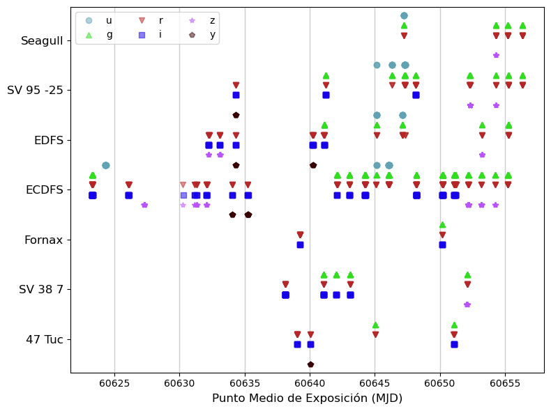

```python
plt.figure(figsize=(8, 6))
spacing = 0.6

for i in range(len(field_names)):
    name = field_names[i]
    ra, dec = field_centers[name]
    offsets = np.sqrt((visits['ra']-ra)**2
                      + (visits['dec']-dec)**2)
    tx = np.where(offsets < 3.0)[0]
    for f, filt in enumerate(filter_names):
        fx = np.where(visits['band'][tx] == filt)[0]
        if len(fx) > 0:
            yval = (i * spacing) - (f * 0.12) + 0.3
            for j in range(len(fx)):
                plt.plot(visits['expMidptMJD'][tx[fx[j]]], yval,
                         filter_symbols[filt], alpha=0.5,
                         color=filter_colors[filt],
                         label=filt if (j == 0) & (i == 3) else None)

yticks = [i * spacing for i in range(len(field_names))]
plt.yticks(yticks, [t for t in field_names], fontsize=12)
plt.xlabel("Punto Medio de Exposición (MJD)", fontsize=12)
plt.grid(axis='x', color='0.8', linewidth=1)
plt.legend(loc='upper left', ncol=3)
plt.ylim(-spacing / 1.5, (len(field_names) - 1) * spacing + spacing / 1.5)
plt.tight_layout()
```

## 4. Calidad de imagen

Usar el servicio TAP para obtener el *seeing* (la visibilidad astronómica) y los límites de magnitud que se evaluaron para todas las `visit_images` (todos los detectores) de la tabla `CcdVisit`.

```python
query = """SELECT visitId, ra, dec, band, seeing, magLim FROM dp1.CcdVisit"""
job = service.submit_job(query)
job.run()
job.wait(phases=['COMPLETED', 'ERROR'])
print('La fase del trabajo es', job.phase)
if job.phase == 'ERROR':
    job.raise_if_error()
```

```
La fase del trabajo es COMPLETED
```

```python
assert job.phase == 'COMPLETED'
ccdvisits = job.fetch_result().to_table()
```

```python
job.delete()
del query
```

### 4.1. *Seeing* (Visibilidad astronómica)

Calcular el *seeing* (visibilidad astronómica) promedio sobre todos los detectores por filtro, y para todos los filtros.

```python
print('Campo      seeing por filtro               media')
print('              u    g    r    i    z    y  ')
for i in range(len(field_names)):
    name = field_names[i]
    ra, dec = field_centers[name]
    offsets = np.sqrt((ccdvisits['ra']-ra)**2
                      + (ccdvisits['dec']-dec)**2)
    tx = np.where(offsets < 3.0)[0]
    tmp = []
    for f, filt in enumerate(filter_names):
        fx = np.where(ccdvisits['band'][tx] == filt)[0]
        if len(fx) > 0:
            tmp.append(str(np.round(np.mean(ccdvisits['seeing'][tx[fx]]), 2)))
        else:
            tmp.append('  - ')
    tmp.append(str(np.round(np.mean(ccdvisits['seeing'][tx]), 2)))
    print('%-10s %-4s %-4s %-4s %-4s %-4s %-4s   %-4s' %
          (name, tmp[0], tmp[1], tmp[2], tmp[3], tmp[4], tmp[5], tmp[6]))
    del name, ra, dec, offsets, tx
```

```
Campo      seeing por filtro               media
              u    g    r    i    z    y
47 Tuc       -  1.47 1.26 1.11   -  1.34   1.25
SV 38 7      -  1.16 1.13 1.11 1.23   -    1.14
Fornax       -  1.16 0.83 0.87   -    -    0.88
ECDFS      1.43 1.17 1.09 1.01 1.0  1.07   1.1
EDFS       1.88 1.2  1.2  1.05 1.17 0.98   1.21
SV 95 -25  1.48 1.24 1.13 0.99 1.23 0.83   1.2
Seagull    1.53 1.26 1.12   -  1.21   -    1.22
```

### 4.2. Límites de magnitud

Calcular el límite de magnitud promedio sobre todos los detectores por filtro, y para todos los filtros.

```python
print('Campo      mag lim por filtro                   media')
print('              u     g     r     i     z     y  ')
for i in range(len(field_names)):
    name = field_names[i]
    ra, dec = field_centers[name]
    offsets = np.sqrt((ccdvisits['ra']-ra)**2
                      + (ccdvisits['dec']-dec)**2)
    tx = np.where(offsets < 3.0)[0]
    tmp = []
    for f, filt in enumerate(filter_names):
        fx = np.where(ccdvisits['band'][tx] == filt)[0]
        if len(fx) > 0:
            tmp.append(str(np.round(np.mean(ccdvisits['magLim'][tx[fx]]), 2)))
        else:
            tmp.append('  - ')
    tmp.append(str(np.round(np.mean(ccdvisits['magLim'][tx]), 2)))
    print('%-10s %-5s %-5s %-5s %-5s %-5s %-5s   %-5s' %
          (name, tmp[0], tmp[1], tmp[2], tmp[3], tmp[4], tmp[5], tmp[6]))
    del name, ra, dec, offsets, tx
```

```
Campo      mag lim por filtro                   media
              u     g     r     i     z     y
47 Tuc       -   24.16 24.28 23.99   -   21.7    23.98
SV 38 7      -   24.45 24.19 23.74 22.9    -     23.94
Fornax       -   24.78 24.74 24.15   -     -     24.58
ECDFS      23.5  24.49 24.15 23.9  23.14 21.94   23.9
EDFS       23.3  24.57 24.15 23.87 23.18 22.15   23.84
SV 95 -25  23.54 24.63 24.36 23.95 23.12 22.17   23.98
Seagull    23.38 24.02 23.76   -   23.18   -     23.76
```

## 5. Profundidad coagregada

Utilizar los mapas de propiedades del relevamiento para imprimir la profundidad coagregada en cada banda en el centro de cada campo.

Cargar los límites de magnitud PSF en cada filtro.

```python
u_maglim = butler.get('deepCoadd_psf_maglim_consolidated_map_weighted_mean',
                      band='u')
g_maglim = butler.get('deepCoadd_psf_maglim_consolidated_map_weighted_mean',
                      band='g')
r_maglim = butler.get('deepCoadd_psf_maglim_consolidated_map_weighted_mean',
                      band='r')
i_maglim = butler.get('deepCoadd_psf_maglim_consolidated_map_weighted_mean',
                      band='i')
z_maglim = butler.get('deepCoadd_psf_maglim_consolidated_map_weighted_mean',
                      band='z')
y_maglim = butler.get('deepCoadd_psf_maglim_consolidated_map_weighted_mean',
                      band='y')
```

Imprimir el valor por filtro en el centro de cada campo. Cuando no haya datos, imprimir "nan". Observar que todas las profundidades para 47 Tuc se evalúan como "nan", y la razón de esto se analiza en la Sección 5.1.

```python
print('Campo      mag lim coagregada por filtro     ')
print('              u     g     r     i     z     y')
for i in range(len(field_names)):
    name = field_names[i]
    ra, dec = field_centers[name]
    lims = np.asarray([u_maglim.get_values_pos(ra, dec),
                       g_maglim.get_values_pos(ra, dec),
                       r_maglim.get_values_pos(ra, dec),
                       i_maglim.get_values_pos(ra, dec),
                       z_maglim.get_values_pos(ra, dec),
                       y_maglim.get_values_pos(ra, dec)], dtype='float')
    tx = np.where(lims < 0.0)[0]
    lims[tx] = float('NaN')
    print('%-10s %5.2f %5.2f %5.2f %5.2f %5.2f %5.2f' %
          (name, lims[0], lims[1], lims[2], lims[3], lims[4], lims[5]))
```

```
Campo      mag lim coagregada por filtro
              u     g     r     i     z     y
47 Tuc       nan   nan   nan   nan   nan   nan
SV 38 7      nan 25.29 25.06 24.72 23.49   nan
Fornax       nan   nan 25.08 25.31   nan   nan
ECDFS      25.18 27.36 27.09 26.50 25.61 23.57
EDFS       23.89 26.53 26.47 25.73 24.98 23.57
SV 95 -25  25.12 26.74 26.53 25.44 25.14 23.28
Seagull    24.32 25.83 25.57   nan 24.09   nan
```

> **¡Advertencia!** La profundidad coagregada en el **centro de 47 Tuc** no se evalúa (no es un número, "nan"). Pasar a la siguiente sección para comprender porqué.

### 5.1. Mapas de profundidad

Graficar los mapas de profundidad en banda *r* para cada campo. Observar que 47 Tuc tiene un “agujero” en el centro, donde el campo era demasiado denso como para que las imágenes pudieran procesarse para la Vista Previa de Datos 1 (DP1). Se están realizando mejoras de software y ajustes de configuración para poder manejar ese tipo de campos tan densamente poblados.

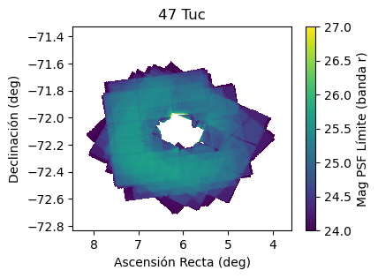

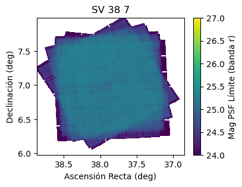

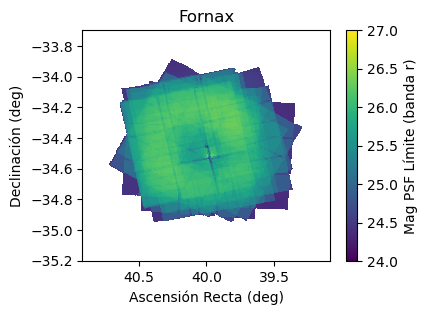

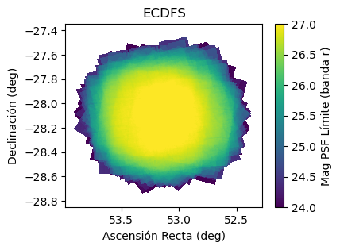

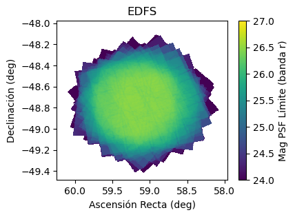

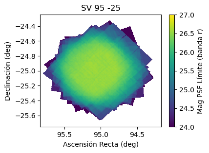

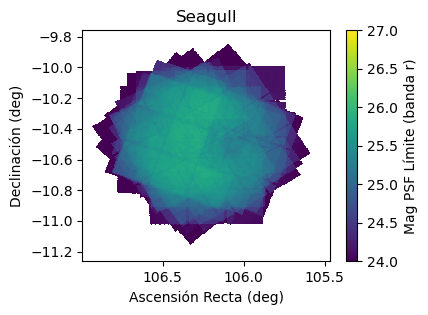

```python
for i in range(len(field_names)):
    name = field_names[i]
    ra_cen, dec_cen = field_centers[name]
    span_dec = 0.75
    if i == 1:
        span_dec = 1.00
    span_ra = span_dec / np.cos(np.deg2rad(dec_cen))
    ra = np.linspace(ra_cen-span_ra, ra_cen+span_ra, 250)
    dec = np.linspace(dec_cen-span_dec, dec_cen+span_dec, 250)
    x, y = np.meshgrid(ra, dec)
    values = r_maglim.get_values_pos(x, y)
    row, col = np.where(values < 0.0)
    values[row, col] = 'NaN'

    fig = plt.figure(figsize=(4, 3))
    plt.pcolormesh(x, y, values, vmin=24.0, vmax=27)
    plt.xlabel("Ascensión Recta (deg)")
    plt.ylabel("Declinación (deg)")
    plt.title(name)
    plt.colorbar(label="Mag PSF Límite (banda r)")
    plt.gca().invert_xaxis()
    plt.show()
```

> **Figura 2:** Siete paneles que muestran el mapa de propiedad de profundidad en banda *r* para cada campo.